# Risk Factor Analysis

## Outcome Variable

**Outcome Variable:** ever_stunted

## Predictor Variables

**Intervention Variable:** mbmi

**Adjustment Set:**

unadjusted

## Stratifying Variables

The analysis was stratified on these variable(s):

- agecat
- studyid

The following strata were considered:

- agecat: 12 months, studyid: ki0047075b-MAL-ED
- agecat: 12 months, studyid: ki1017093-NIH-Birth
- agecat: 12 months, studyid: ki1017093b-PROVIDE
- agecat: 12 months, studyid: ki1017093c-NIH-Crypto
- agecat: 12 months, studyid: ki1066203-TanzaniaChild2
- agecat: 12 months, studyid: ki1126311-ZVITAMBO
- agecat: 12 months, studyid: ki1148112-LCNI-5
- agecat: 18 months, studyid: ki0047075b-MAL-ED
- agecat: 18 months, studyid: ki1017093-NIH-Birth
- agecat: 18 months, studyid: ki1017093b-PROVIDE
- agecat: 18 months, studyid: ki1017093c-NIH-Crypto
- agecat: 18 months, studyid: ki1066203-TanzaniaChild2
- agecat: 18 months, studyid: ki1126311-ZVITAMBO
- agecat: 18 months, studyid: ki1148112-LCNI-5
- agecat: 24 months, studyid: ki0047075b-MAL-ED
- agecat: 24 months, studyid: ki1017093-NIH-Birth
- agecat: 24 months, studyid: ki1017093b-PROVIDE
- agecat: 24 months, studyid: ki1017093c-NIH-Crypto
- agecat: 24 months, studyid: ki1066203-TanzaniaChild2
- agecat: 24 months, studyid: ki1126311-ZVITAMBO
- agecat: 24 months, studyid: ki1148112-LCNI-5
- agecat: 3 months, studyid: ki0047075b-MAL-ED
- agecat: 3 months, studyid: ki1017093-NIH-Birth
- agecat: 3 months, studyid: ki1017093b-PROVIDE
- agecat: 3 months, studyid: ki1017093c-NIH-Crypto
- agecat: 3 months, studyid: ki1066203-TanzaniaChild2
- agecat: 3 months, studyid: ki1126311-ZVITAMBO
- agecat: 6 months, studyid: ki0047075b-MAL-ED
- agecat: 6 months, studyid: ki1017093-NIH-Birth
- agecat: 6 months, studyid: ki1017093b-PROVIDE
- agecat: 6 months, studyid: ki1017093c-NIH-Crypto
- agecat: 6 months, studyid: ki1066203-TanzaniaChild2
- agecat: 6 months, studyid: ki1126311-ZVITAMBO
- agecat: 6 months, studyid: ki1148112-LCNI-5

### Dropped Strata

Some strata were dropped due to rare outcomes:

- agecat: 3 months, studyid: ki1066203-TanzaniaChild2
- agecat: 6 months, studyid: ki1066203-TanzaniaChild2
- agecat: 6 months, studyid: ki1148112-LCNI-5
- agecat: 12 months, studyid: ki1066203-TanzaniaChild2
- agecat: 18 months, studyid: ki1066203-TanzaniaChild2
- agecat: 24 months, studyid: ki1066203-TanzaniaChild2

## Methods Detail

We’re interested in the causal parameters $E[Y_a]$ for all values of $a \in \mathcal{A}$. These parameters represent the mean outcome if, possibly contrary to fact, we intervened to set all units to have $A=a$. Under the randomization and positivity assumptions, these are identified by the statistical parameters $\psi_a=E_W[E_{Y|A,W}(Y|A=a,W)]$. In addition, we’re interested in the mean of $Y$, $E[Y]$ under no intervention (the observed mean). We will estimate these parameters by using SuperLearner to fit the relevant likelihood factors – $E_{Y|A,W}(Y|A=a,W)$ and $p(A=a|W)$, and then updating our likelihood fit using a joint TMLE.

For unadjusted analyses ($W=\{\}$), initial likelihoods were estimated using Lrnr_glm to estimate the simple $E(Y|A)$ and Lrnr_mean to estimate $p(A)$. For adjusted analyses, a small library containing Lrnr_glmnet, Lrnr_xgboost, and Lrnr_mean was used.

Having estimated these parameters, we will then use the delta method to estimate relative risks and attributable risks relative to a prespecified baseline level of $A$.

# Results Detail

## Results Plots

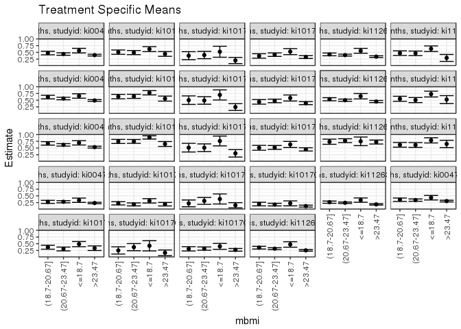

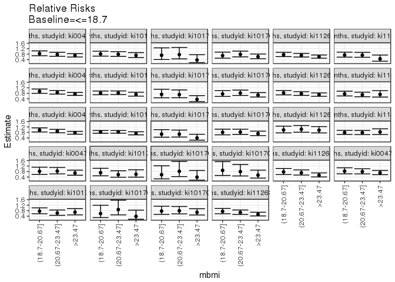

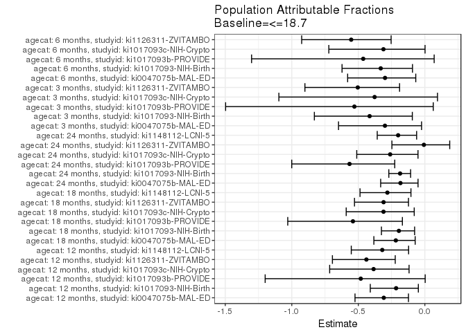

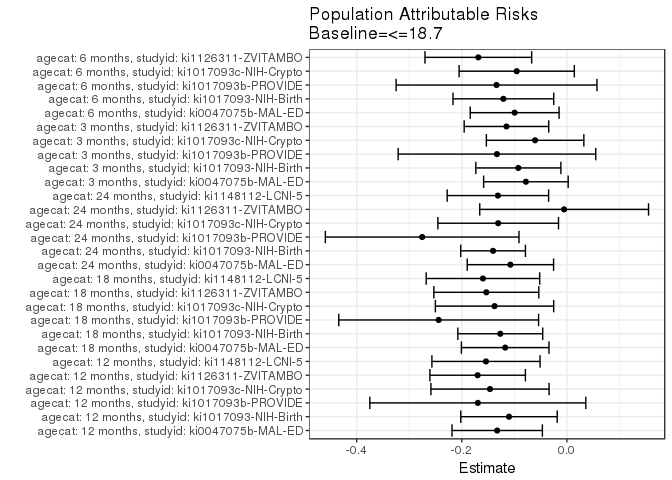

## Data Summary

| agecat | studyid | A | n | nA | nAY0 | nAY1 |
| --- | --- | --- | --- | --- | --- | --- |
| 3 months | ki0047075b-MAL-ED | <=18.7 | 1771 | 133 | 88 | 45 |
| 3 months | ki0047075b-MAL-ED | (18.7-20.67] | 1771 | 232 | 168 | 64 |
| 3 months | ki0047075b-MAL-ED | (20.67-23.47] | 1771 | 488 | 351 | 137 |
| 3 months | ki0047075b-MAL-ED | >23.47 | 1771 | 918 | 703 | 215 |
| 3 months | ki1017093-NIH-Birth | <=18.7 | 629 | 127 | 87 | 40 |
| 3 months | ki1017093-NIH-Birth | (18.7-20.67] | 629 | 178 | 138 | 40 |
| 3 months | ki1017093-NIH-Birth | (20.67-23.47] | 629 | 187 | 153 | 34 |
| 3 months | ki1017093-NIH-Birth | >23.47 | 629 | 137 | 111 | 26 |
| 3 months | ki1017093b-PROVIDE | <=18.7 | 171 | 26 | 16 | 10 |
| 3 months | ki1017093b-PROVIDE | (18.7-20.67] | 171 | 41 | 32 | 9 |
| 3 months | ki1017093b-PROVIDE | (20.67-23.47] | 171 | 51 | 35 | 16 |
| 3 months | ki1017093b-PROVIDE | >23.47 | 171 | 53 | 45 | 8 |
| 3 months | ki1017093c-NIH-Crypto | <=18.7 | 755 | 77 | 60 | 17 |
| 3 months | ki1017093c-NIH-Crypto | (18.7-20.67] | 755 | 133 | 107 | 26 |
| 3 months | ki1017093c-NIH-Crypto | (20.67-23.47] | 755 | 234 | 193 | 41 |
| 3 months | ki1017093c-NIH-Crypto | >23.47 | 755 | 311 | 274 | 37 |
| 3 months | ki1066203-TanzaniaChild2 | <=18.7 | 592 | 7 | 6 | 1 |
| 3 months | ki1066203-TanzaniaChild2 | (18.7-20.67] | 592 | 66 | 57 | 9 |
| 3 months | ki1066203-TanzaniaChild2 | (20.67-23.47] | 592 | 156 | 136 | 20 |
| 3 months | ki1066203-TanzaniaChild2 | >23.47 | 592 | 363 | 334 | 29 |
| 3 months | ki1126311-ZVITAMBO | <=18.7 | 2423 | 134 | 88 | 46 |
| 3 months | ki1126311-ZVITAMBO | (18.7-20.67] | 2423 | 440 | 323 | 117 |
| 3 months | ki1126311-ZVITAMBO | (20.67-23.47] | 2423 | 861 | 652 | 209 |
| 3 months | ki1126311-ZVITAMBO | >23.47 | 2423 | 988 | 807 | 181 |
| 3 months | ki1148112-LCNI-5 | <=18.7 | 0 | 0 | 0 | 0 |
| 3 months | ki1148112-LCNI-5 | (18.7-20.67] | 0 | 0 | 0 | 0 |
| 3 months | ki1148112-LCNI-5 | (20.67-23.47] | 0 | 0 | 0 | 0 |
| 3 months | ki1148112-LCNI-5 | >23.47 | 0 | 0 | 0 | 0 |
| 6 months | ki0047075b-MAL-ED | <=18.7 | 1736 | 132 | 75 | 57 |
| 6 months | ki0047075b-MAL-ED | (18.7-20.67] | 1736 | 224 | 144 | 80 |

[output cut: 110 more lines]

## Results Table

### Parameter: TSM

| agecat | studyid | intervention_level | baseline_level | estimate | ci_lower | ci_upper |
| --- | --- | --- | --- | --- | --- | --- |
| 3 months | ki0047075b-MAL-ED | <=18.7 | NA | 0.3383459 | 0.2579116 | 0.4187801 |
| 3 months | ki0047075b-MAL-ED | (18.7-20.67] | NA | 0.2758621 | 0.2183335 | 0.3333906 |
| 3 months | ki0047075b-MAL-ED | (20.67-23.47] | NA | 0.2807377 | 0.2408577 | 0.3206177 |
| 3 months | ki0047075b-MAL-ED | >23.47 | NA | 0.2342048 | 0.2068014 | 0.2616081 |
| 3 months | ki1017093-NIH-Birth | <=18.7 | NA | 0.3149606 | 0.2341111 | 0.3958102 |
| 3 months | ki1017093-NIH-Birth | (18.7-20.67] | NA | 0.2247191 | 0.1633524 | 0.2860859 |
| 3 months | ki1017093-NIH-Birth | (20.67-23.47] | NA | 0.1818182 | 0.1264938 | 0.2371425 |
| 3 months | ki1017093-NIH-Birth | >23.47 | NA | 0.1897810 | 0.1240666 | 0.2554955 |
| 3 months | ki1017093b-PROVIDE | <=18.7 | NA | 0.3846154 | 0.1970634 | 0.5721674 |
| 3 months | ki1017093b-PROVIDE | (18.7-20.67] | NA | 0.2195122 | 0.0924425 | 0.3465819 |
| 3 months | ki1017093b-PROVIDE | (20.67-23.47] | NA | 0.3137255 | 0.1860050 | 0.4414459 |
| 3 months | ki1017093b-PROVIDE | >23.47 | NA | 0.1509434 | 0.0542806 | 0.2476061 |
| 3 months | ki1017093c-NIH-Crypto | <=18.7 | NA | 0.2207792 | 0.1280749 | 0.3134835 |
| 3 months | ki1017093c-NIH-Crypto | (18.7-20.67] | NA | 0.1954887 | 0.1280457 | 0.2629317 |
| 3 months | ki1017093c-NIH-Crypto | (20.67-23.47] | NA | 0.1752137 | 0.1264740 | 0.2239534 |
| 3 months | ki1017093c-NIH-Crypto | >23.47 | NA | 0.1189711 | 0.0829653 | 0.1549768 |
| 3 months | ki1126311-ZVITAMBO | <=18.7 | NA | 0.3432836 | 0.2628753 | 0.4236919 |
| 3 months | ki1126311-ZVITAMBO | (18.7-20.67] | NA | 0.2659091 | 0.2246183 | 0.3071999 |
| 3 months | ki1126311-ZVITAMBO | (20.67-23.47] | NA | 0.2427410 | 0.2140972 | 0.2713848 |
| 3 months | ki1126311-ZVITAMBO | >23.47 | NA | 0.1831984 | 0.1590728 | 0.2073240 |
| 6 months | ki0047075b-MAL-ED | <=18.7 | NA | 0.4318182 | 0.3472941 | 0.5163422 |
| 6 months | ki0047075b-MAL-ED | (18.7-20.67] | NA | 0.3571429 | 0.2943764 | 0.4199093 |
| 6 months | ki0047075b-MAL-ED | (20.67-23.47] | NA | 0.3430962 | 0.3005248 | 0.3856677 |
| 6 months | ki0047075b-MAL-ED | >23.47 | NA | 0.3059867 | 0.2759048 | 0.3360686 |
| 6 months | ki1017093-NIH-Birth | <=18.7 | NA | 0.4857143 | 0.3900300 | 0.5813986 |
| 6 months | ki1017093-NIH-Birth | (18.7-20.67] | NA | 0.3696970 | 0.2959748 | 0.4434192 |
| 6 months | ki1017093-NIH-Birth | (20.67-23.47] | NA | 0.3048780 | 0.2343577 | 0.3753984 |
| 6 months | ki1017093-NIH-Birth | >23.47 | NA | 0.3333333 | 0.2478378 | 0.4188289 |
| 6 months | ki1017093b-PROVIDE | <=18.7 | NA | 0.4230769 | 0.2326001 | 0.6135537 |
| 6 months | ki1017093b-PROVIDE | (18.7-20.67] | NA | 0.2500000 | 0.1154044 | 0.3845956 |

[output cut: 82 more lines]

### Parameter: E(Y)

| agecat | studyid | intervention_level | baseline_level | estimate | ci_lower | ci_upper |
| --- | --- | --- | --- | --- | --- | --- |
| 3 months | ki0047075b-MAL-ED | NA | NA | 0.2603049 | 0.2588636 | 0.2617463 |
| 3 months | ki1017093-NIH-Birth | NA | NA | 0.2225755 | 0.2187021 | 0.2264489 |
| 3 months | ki1017093b-PROVIDE | NA | NA | 0.2514620 | 0.2386816 | 0.2642424 |
| 3 months | ki1017093c-NIH-Crypto | NA | NA | 0.1602649 | 0.1576290 | 0.1629008 |
| 3 months | ki1126311-ZVITAMBO | NA | NA | 0.2282295 | 0.2264974 | 0.2299616 |
| 6 months | ki0047075b-MAL-ED | NA | NA | 0.3323733 | 0.3307267 | 0.3340199 |
| 6 months | ki1017093-NIH-Birth | NA | NA | 0.3647913 | 0.3594582 | 0.3701244 |
| 6 months | ki1017093b-PROVIDE | NA | NA | 0.2891566 | 0.2739035 | 0.3044098 |
| 6 months | ki1017093c-NIH-Crypto | NA | NA | 0.3070652 | 0.3042748 | 0.3098556 |
| 6 months | ki1126311-ZVITAMBO | NA | NA | 0.3045311 | 0.3020876 | 0.3069746 |
| 12 months | ki0047075b-MAL-ED | NA | NA | 0.4298454 | 0.4276007 | 0.4320902 |
| 12 months | ki1017093-NIH-Birth | NA | NA | 0.5101664 | 0.5051098 | 0.5152229 |
| 12 months | ki1017093b-PROVIDE | NA | NA | 0.3522013 | 0.3350513 | 0.3693512 |
| 12 months | ki1017093c-NIH-Crypto | NA | NA | 0.3799726 | 0.3754816 | 0.3844635 |
| 12 months | ki1126311-ZVITAMBO | NA | NA | 0.3866602 | 0.3843950 | 0.3889254 |
| 12 months | ki1148112-LCNI-5 | NA | NA | 0.4812968 | 0.4717520 | 0.4908415 |
| 18 months | ki0047075b-MAL-ED | NA | NA | 0.5385572 | 0.5357590 | 0.5413554 |
| 18 months | ki1017093-NIH-Birth | NA | NA | 0.6498994 | 0.6435523 | 0.6562465 |
| 18 months | ki1017093b-PROVIDE | NA | NA | 0.4516129 | 0.4280105 | 0.4752153 |
| 18 months | ki1017093c-NIH-Crypto | NA | NA | 0.4433566 | 0.4390734 | 0.4476399 |
| 18 months | ki1126311-ZVITAMBO | NA | NA | 0.4943671 | 0.4918505 | 0.4968837 |
| 18 months | ki1148112-LCNI-5 | NA | NA | 0.5674847 | 0.5584884 | 0.5764809 |
| 24 months | ki0047075b-MAL-ED | NA | NA | 0.5867014 | 0.5836681 | 0.5897348 |
| 24 months | ki1017093-NIH-Birth | NA | NA | 0.7553191 | 0.7480021 | 0.7626362 |
| 24 months | ki1017093b-PROVIDE | NA | NA | 0.4864865 | 0.4630689 | 0.5099041 |
| 24 months | ki1017093c-NIH-Crypto | NA | NA | 0.5015773 | 0.4972756 | 0.5058790 |
| 24 months | ki1126311-ZVITAMBO | NA | NA | 0.7447368 | 0.7425558 | 0.7469179 |
| 24 months | ki1148112-LCNI-5 | NA | NA | 0.6543909 | 0.6474469 | 0.6613349 |

### Parameter: RR

| agecat | studyid | intervention_level | baseline_level | estimate | ci_lower | ci_upper |
| --- | --- | --- | --- | --- | --- | --- |
| 3 months | ki0047075b-MAL-ED | (18.7-20.67] | <=18.7 | 0.8153257 | 0.5942819 | 1.1185869 |
| 3 months | ki0047075b-MAL-ED | (20.67-23.47] | <=18.7 | 0.8297359 | 0.6290249 | 1.0944903 |
| 3 months | ki0047075b-MAL-ED | >23.47 | <=18.7 | 0.6922053 | 0.5310842 | 0.9022076 |
| 3 months | ki1017093-NIH-Birth | (18.7-20.67] | <=18.7 | 0.7134831 | 0.4904724 | 1.0378936 |
| 3 months | ki1017093-NIH-Birth | (20.67-23.47] | <=18.7 | 0.5772727 | 0.3876941 | 0.8595535 |
| 3 months | ki1017093-NIH-Birth | >23.47 | <=18.7 | 0.6025547 | 0.3915612 | 0.9272427 |
| 3 months | ki1017093b-PROVIDE | (18.7-20.67] | <=18.7 | 0.5707317 | 0.2677435 | 1.2165924 |
| 3 months | ki1017093b-PROVIDE | (20.67-23.47] | <=18.7 | 0.8156863 | 0.4321588 | 1.5395825 |
| 3 months | ki1017093b-PROVIDE | >23.47 | <=18.7 | 0.3924528 | 0.1754758 | 0.8777233 |
| 3 months | ki1017093c-NIH-Crypto | (18.7-20.67] | <=18.7 | 0.8854489 | 0.5142178 | 1.5246842 |
| 3 months | ki1017093c-NIH-Crypto | (20.67-23.47] | <=18.7 | 0.7936149 | 0.4795840 | 1.3132726 |
| 3 months | ki1017093c-NIH-Crypto | >23.47 | <=18.7 | 0.5388689 | 0.3211399 | 0.9042157 |
| 3 months | ki1126311-ZVITAMBO | (18.7-20.67] | <=18.7 | 0.7746047 | 0.5848315 | 1.0259579 |
| 3 months | ki1126311-ZVITAMBO | (20.67-23.47] | <=18.7 | 0.7071151 | 0.5439820 | 0.9191696 |
| 3 months | ki1126311-ZVITAMBO | >23.47 | <=18.7 | 0.5336648 | 0.4079128 | 0.6981840 |
| 6 months | ki0047075b-MAL-ED | (18.7-20.67] | <=18.7 | 0.8270677 | 0.6357632 | 1.0759367 |
| 6 months | ki0047075b-MAL-ED | (20.67-23.47] | <=18.7 | 0.7945386 | 0.6301812 | 1.0017621 |
| 6 months | ki0047075b-MAL-ED | >23.47 | <=18.7 | 0.7086008 | 0.5692107 | 0.8821250 |
| 6 months | ki1017093-NIH-Birth | (18.7-20.67] | <=18.7 | 0.7611408 | 0.5750801 | 1.0073994 |
| 6 months | ki1017093-NIH-Birth | (20.67-23.47] | <=18.7 | 0.6276901 | 0.4632283 | 0.8505414 |
| 6 months | ki1017093-NIH-Birth | >23.47 | <=18.7 | 0.6862745 | 0.4966418 | 0.9483147 |
| 6 months | ki1017093b-PROVIDE | (18.7-20.67] | <=18.7 | 0.5909091 | 0.2929031 | 1.1921128 |
| 6 months | ki1017093b-PROVIDE | (20.67-23.47] | <=18.7 | 0.8805704 | 0.4956308 | 1.5644794 |
| 6 months | ki1017093b-PROVIDE | >23.47 | <=18.7 | 0.3858998 | 0.1770672 | 0.8410291 |
| 6 months | ki1017093c-NIH-Crypto | (18.7-20.67] | <=18.7 | 0.7701925 | 0.5294492 | 1.1204032 |
| 6 months | ki1017093c-NIH-Crypto | (20.67-23.47] | <=18.7 | 0.7918017 | 0.5682770 | 1.1032470 |
| 6 months | ki1017093c-NIH-Crypto | >23.47 | <=18.7 | 0.6766692 | 0.4869456 | 0.9403128 |
| 6 months | ki1126311-ZVITAMBO | (18.7-20.67] | <=18.7 | 0.7467338 | 0.5763379 | 0.9675077 |
| 6 months | ki1126311-ZVITAMBO | (20.67-23.47] | <=18.7 | 0.6681034 | 0.5251420 | 0.8499838 |
| 6 months | ki1126311-ZVITAMBO | >23.47 | <=18.7 | 0.5345455 | 0.4178385 | 0.6838499 |

[output cut: 54 more lines]

### Parameter: PAR

| agecat | studyid | intervention_level | baseline_level | estimate | ci_lower | ci_upper |
| --- | --- | --- | --- | --- | --- | --- |
| 3 months | ki0047075b-MAL-ED | <=18.7 | NA | -0.0780410 | -0.1584881 | 0.0024062 |
| 3 months | ki1017093-NIH-Birth | <=18.7 | NA | -0.0923851 | -0.1733274 | -0.0114428 |
| 3 months | ki1017093b-PROVIDE | <=18.7 | NA | -0.1331534 | -0.3211403 | 0.0548335 |
| 3 months | ki1017093c-NIH-Crypto | <=18.7 | NA | -0.0605143 | -0.1532561 | 0.0322274 |
| 3 months | ki1126311-ZVITAMBO | <=18.7 | NA | -0.1150541 | -0.1954811 | -0.0346272 |
| 6 months | ki0047075b-MAL-ED | <=18.7 | NA | -0.0994449 | -0.1839850 | -0.0149048 |
| 6 months | ki1017093-NIH-Birth | <=18.7 | NA | -0.1209230 | -0.2167558 | -0.0250902 |
| 6 months | ki1017093b-PROVIDE | <=18.7 | NA | -0.1339203 | -0.3250069 | 0.0571663 |
| 6 months | ki1017093c-NIH-Crypto | <=18.7 | NA | -0.0955322 | -0.2051819 | 0.0141176 |
| 6 months | ki1126311-ZVITAMBO | <=18.7 | NA | -0.1685872 | -0.2701158 | -0.0670586 |
| 12 months | ki0047075b-MAL-ED | <=18.7 | NA | -0.1326546 | -0.2186491 | -0.0466601 |
| 12 months | ki1017093-NIH-Birth | <=18.7 | NA | -0.1102040 | -0.2019536 | -0.0184544 |
| 12 months | ki1017093b-PROVIDE | <=18.7 | NA | -0.1695379 | -0.3750469 | 0.0359711 |
| 12 months | ki1017093c-NIH-Crypto | <=18.7 | NA | -0.1463432 | -0.2587659 | -0.0339206 |
| 12 months | ki1126311-ZVITAMBO | <=18.7 | NA | -0.1698615 | -0.2607097 | -0.0790133 |
| 12 months | ki1148112-LCNI-5 | <=18.7 | NA | -0.1539974 | -0.2568975 | -0.0510972 |
| 18 months | ki0047075b-MAL-ED | <=18.7 | NA | -0.1174428 | -0.2007925 | -0.0340931 |
| 18 months | ki1017093-NIH-Birth | <=18.7 | NA | -0.1267996 | -0.2075573 | -0.0460419 |
| 18 months | ki1017093b-PROVIDE | <=18.7 | NA | -0.2440393 | -0.4341661 | -0.0539125 |
| 18 months | ki1017093c-NIH-Crypto | <=18.7 | NA | -0.1377244 | -0.2502974 | -0.0251515 |
| 18 months | ki1126311-ZVITAMBO | <=18.7 | NA | -0.1533601 | -0.2532277 | -0.0534926 |
| 18 months | ki1148112-LCNI-5 | <=18.7 | NA | -0.1597881 | -0.2677743 | -0.0518018 |
| 24 months | ki0047075b-MAL-ED | <=18.7 | NA | -0.1075134 | -0.1896901 | -0.0253368 |
| 24 months | ki1017093-NIH-Birth | <=18.7 | NA | -0.1405142 | -0.2021223 | -0.0789061 |
| 24 months | ki1017093b-PROVIDE | <=18.7 | NA | -0.2754183 | -0.4596955 | -0.0911411 |
| 24 months | ki1017093c-NIH-Crypto | <=18.7 | NA | -0.1307757 | -0.2455479 | -0.0160034 |
| 24 months | ki1126311-ZVITAMBO | <=18.7 | NA | -0.0052632 | -0.1658766 | 0.1553503 |
| 24 months | ki1148112-LCNI-5 | <=18.7 | NA | -0.1313234 | -0.2278331 | -0.0348136 |

### Parameter: PAF

| agecat | studyid | intervention_level | baseline_level | estimate | ci_lower | ci_upper |
| --- | --- | --- | --- | --- | --- | --- |
| 3 months | ki0047075b-MAL-ED | <=18.7 | NA | -0.2998059 | -0.6487332 | -0.0247233 |
| 3 months | ki1017093-NIH-Birth | <=18.7 | NA | -0.4150731 | -0.8302778 | -0.0940590 |
| 3 months | ki1017093b-PROVIDE | <=18.7 | NA | -0.5295170 | -1.4973461 | 0.0632367 |
| 3 months | ki1017093c-NIH-Crypto | <=18.7 | NA | -0.3775894 | -1.0970950 | 0.0950565 |
| 3 months | ki1126311-ZVITAMBO | <=18.7 | NA | -0.5041159 | -0.9013441 | -0.1898766 |
| 6 months | ki0047075b-MAL-ED | <=18.7 | NA | -0.2991965 | -0.5801955 | -0.0681662 |
| 6 months | ki1017093-NIH-Birth | <=18.7 | NA | -0.3314854 | -0.6222823 | -0.0928144 |
| 6 months | ki1017093b-PROVIDE | <=18.7 | NA | -0.4631410 | -1.3022415 | 0.0701316 |
| 6 months | ki1017093c-NIH-Crypto | <=18.7 | NA | -0.3111137 | -0.7216724 | 0.0015412 |
| 6 months | ki1126311-ZVITAMBO | <=18.7 | NA | -0.5535960 | -0.9256327 | -0.2534377 |
| 12 months | ki0047075b-MAL-ED | <=18.7 | NA | -0.3086100 | -0.5248280 | -0.1230512 |
| 12 months | ki1017093-NIH-Birth | <=18.7 | NA | -0.2160158 | -0.4099893 | -0.0487275 |
| 12 months | ki1017093b-PROVIDE | <=18.7 | NA | -0.4813665 | -1.2000763 | 0.0025589 |
| 12 months | ki1017093c-NIH-Crypto | <=18.7 | NA | -0.3851416 | -0.7152552 | -0.1185607 |
| 12 months | ki1126311-ZVITAMBO | <=18.7 | NA | -0.4393043 | -0.6946177 | -0.2224568 |
| 12 months | ki1148112-LCNI-5 | <=18.7 | NA | -0.3199634 | -0.5528515 | -0.1220026 |
| 18 months | ki0047075b-MAL-ED | <=18.7 | NA | -0.2180693 | -0.3831440 | -0.0726958 |
| 18 months | ki1017093-NIH-Birth | <=18.7 | NA | -0.1951066 | -0.3262406 | -0.0769386 |
| 18 months | ki1017093b-PROVIDE | <=18.7 | NA | -0.5403727 | -1.0303484 | -0.1686408 |
| 18 months | ki1017093c-NIH-Crypto | <=18.7 | NA | -0.3106403 | -0.5909744 | -0.0797019 |
| 18 months | ki1126311-ZVITAMBO | <=18.7 | NA | -0.3102151 | -0.5286849 | -0.1229676 |
| 18 months | ki1148112-LCNI-5 | <=18.7 | NA | -0.2815725 | -0.4872066 | -0.1043711 |
| 24 months | ki0047075b-MAL-ED | <=18.7 | NA | -0.1832507 | -0.3319862 | -0.0511237 |
| 24 months | ki1017093-NIH-Birth | <=18.7 | NA | -0.1860329 | -0.2707189 | -0.1069906 |
| 24 months | ki1017093b-PROVIDE | <=18.7 | NA | -0.5661376 | -1.0002997 | -0.2262097 |
| 24 months | ki1017093c-NIH-Crypto | <=18.7 | NA | -0.2607288 | -0.5117463 | -0.0513915 |
| 24 months | ki1126311-ZVITAMBO | <=18.7 | NA | -0.0070671 | -0.2475652 | 0.1870692 |
| 24 months | ki1148112-LCNI-5 | <=18.7 | NA | -0.2006803 | -0.3577911 | -0.0617488 |